# Luke Schwenke

### Machine Learning & Predictive Analytics

#### Final Project: Classifying Cars Using Deep Learning

#### May 27, 2023

The Cars dataset contains 16,185 images of 196 classes of cars. The data is split into 8,144 training images and 8,041 testing images, where each class has been split roughly in a 50-50 split. Classes are typically at the level of Make, Model, Year, ex. 2012 Tesla Model S or 2012 BMW M3 coupe.

The data has been downloaded locally and is stored in train/test folders with folders containing images of the specific cars

#### Import required libraries

```python
from PIL import Image
import scipy.io
import os
import matplotlib.pyplot as plt
import csv
import keras
from keras.preprocessing.image import ImageDataGenerator
from keras.applications import densenet
from keras.models import Sequential, Model, load_model
from keras.layers import Conv2D, MaxPooling2D
from keras.layers import Activation, Dropout, Flatten, Dense
from keras.callbacks import EarlyStopping, ReduceLROnPlateau, ModelCheckpoint, Callback
from keras import regularizers
from keras import backend as k
import tensorflow_hub as hub
import tensorflow as tf
from tensorflow.keras.layers import GlobalAveragePooling2D
from keras.optimizers import SGD, Adam
from tensorflow.keras.models import load_model

from classification_models.keras import Classifiers
```

```python
print(tf.config.list_physical_devices('GPU'))
```

```
[]
```

```python
from tensorflow.python.client import device_lib

def get_available_devices():
    local_device_protos = device_lib.list_local_devices()
    return [x.name for x in local_device_protos]

print(get_available_devices())
```

```
['/device:CPU:0']
```

#### Example Image

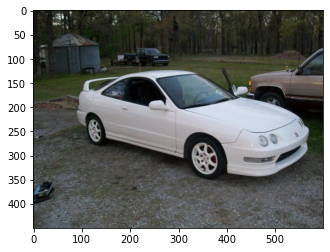

```python
path_base = './data/car_data/'

image = Image.open(path_base + 'car_data/train/Acura Integra Type R 2001/00198.jpg')
imgplot = plt.imshow(image)
plt.show()
```

### Get the Class Labels

```python
class_names = []

with open('./data/names.csv') as csvDataFile:
    csvReader = csv.reader(csvDataFile, delimiter=';')
    for row in csvReader:
        class_names.append(row[0])

print(set(class_names))
```

```
{'Acura ZDX Hatchback 2012', 'Rolls-Royce Phantom Drophead Coupe Convertible 2012', 'Chevrolet Silverado 1500 Hybrid Crew Cab 2012', 'Audi A5 Coupe 2012', 'Chevrolet Express Van 2007', 'Dodge Sprinter Cargo Van 2009', 'Dodge Caliber Wagon 2012', 'Dodge Durango SUV 2012', 'Hyundai Elantra Touring Hat…
```

```python
# This indicates that we are in training mode
k.set_learning_phase(1)
```

#### Specify Parameters

```python
# Ensures images will be square in shape
img_width, img_height = 224, 224

# Number of images in the Train set
nb_train_samples = 8144

# Number of images in the Test set
nb_validation_samples = 8041

# Other Parameters for a base model. Later I perform a Grid Search.
epochs = 20     # Number of complete iterations through the training set
batch_size = 32 # Number of data points that are processed during training
n_classes = 196 # Number of distinct car classes we will classify
```

#### Data Pre-Processing & Augmentation

```python
train_data_dir = path_base + '/car_data/train'
validation_data_dir = path_base + '/car_data/test'

train_datagen = ImageDataGenerator(
    rescale=1./255,          # Normalize the pixel values between 0 and 1
    shear_range=0.2,         # Tilts the image by a maximum radian amount
    zoom_range=0.2,          # Zooms in/out by a maximum factor
    fill_mode = 'constant',  # Method to fill empty pixels resulting from transformations
    cval = 1,                # Constant value - in this case, White
    rotation_range = 5,      # Rotates the image by a maximum +/- degree
    width_shift_range=0.2,   # Maximum horizontal shift in either direction
    height_shift_range=0.2,  # Maximum vertical shift in either direction
    horizontal_flip=True)    # Allows random horizontal flipping

# For the Test data, we will only rescale it
test_datagen = ImageDataGenerator(rescale=1./255)

train_generator = train_datagen.flow_from_directory(
    train_data_dir,
    target_size=(img_width, img_height),
    batch_size=batch_size,
    class_mode='categorical')

validation_generator = test_datagen.flow_from_directory(
    validation_data_dir,
    target_size=(img_width, img_height),
    batch_size=batch_size,
    class_mode='categorical')
```

```
Found 8144 images belonging to 196 classes.
Found 8041 images belonging to 196 classes.
```

```python
print("Train Image shape:", train_generator.image_shape)
print("Test Image shape:", validation_generator.image_shape)
```

```
Train Image shape: (224, 224, 3)
Test Image shape: (224, 224, 3)
```

### Classifiers

Below is a list of pre-trained models we can use via Transfer Learning

```python
Classifiers.models_names()
```

```
['resnet18',
 'resnet34',
 'resnet50',
 'resnet101',
 'resnet152',
 'seresnet18',
 'seresnet34',
 'seresnet50',
 'seresnet101',
 'seresnet152',
 'seresnext50',
 'seresnext101',
 'senet154',
 'resnet50v2',
 'resnet101v2',
 'resnet152v2',
 'resnext50',
 'resnext101',
 'vgg16',
 'vgg19',
 'densenet121',
 'densenet169',
 'densenet201',
 'inceptionresnetv2',
 'inceptionv3',
 'xception',
 'nasnetlarge',
 'nasnetmobile',
 'mobilenet',
 'mobilenetv2']
```

## Model 1: ResNet50

This first iteration of the model uses ResNet50 which is a pretrained model that has starting weights. I add in some final layers including the output softmax layer.

Softmax is used to select the class with the highest probability in terms of classifying the car as the final result. It does this by transforming the previous layer output into a probability distribution over the classes (ensures the predicted class probabilities sum to 1).

```python
# Clear previous session (release GPU memory resources by resetting backend state)
k.clear_session()

# Load in ResNet50
ResNet50, preprocess_input = Classifiers.get('resnet50')
```

```python
# Create the base model
base_model = ResNet50(input_shape=(img_width, img_height, 3),
                      weights='imagenet', # Use imagenet weights
                      include_top=False)  # Ignore the top layer so we can add our own
```

```python
# Extract the output from the base model we created
x = base_model.output

# Add a Pooling Layer to flatten the output of ResNet into 1-D tensor
x = keras.layers.GlobalAveragePooling2D()(x)

# Use Softmax to perform the final layer classification
predictions = Dense(units=train_generator.num_classes,
                    activation= 'softmax')(x)

# Establish the new model with the outputs and base model
model = Model(inputs = base_model.input,
              outputs = predictions)

# Compile the model
model.compile(optimizer = 'adam',
              loss='categorical_crossentropy',
              metrics=['acc'])

# Show summary
model.summary()
```

```
Model: "model_1"
__________________________________________________________________________________________________
 Layer (type)                   Output Shape         Param #     Connected to
==================================================================================================
 data (InputLayer)              [(None, 224, 224, 3  0           []
                                )]

 bn_data (BatchNormalization)   (None, 224, 224, 3)  9           ['data[0][0]']

 zero_padding2d (ZeroPadding2D)  (None, 230, 230, 3)  0          ['bn_data[0][0]']

 conv0 (Conv2D)                 (None, 112, 112, 64  9408        ['zero_padding2d[0][0]']
                                )

 bn0 (BatchNormalization)       (None, 112, 112, 64  256         ['conv0[0][0]']
                                )

 relu0 (Activation)             (None, 112, 112, 64  0           ['bn0[0][0]']
                                )

 zero_padding2d_1 (ZeroPadding2  (None, 114, 114, 64  0          ['relu0[0][0]']
 D)                             )

 pooling0 (MaxPooling2D)        (None, 56, 56, 64)   0           ['zero_padding2d_1[0][0]']

 stage1_unit1_bn1 (BatchNormali  (None, 56, 56, 64)  256         ['pooling0[0][0]']
 zation)

 stage1_unit1_relu1 (Activation  (None, 56, 56, 64)  0           ['stage1_unit1_bn1[0][0]']
 )

 stage1_unit1_conv1 (Conv2D)    (None, 56, 56, 64)   4096        ['stage1_unit1_relu1[0][0]']

 stage1_unit1_bn2 (BatchNormali  (None, 56, 56, 64)  256         ['stage1_unit1_conv1[0][0]']
 zation)

 stage1_unit1_relu2 (Activation  (None, 56, 56, 64)  0           ['stage1_unit1_bn2[0][0]']
 )

 zero_padding2d_2 (ZeroPadding2  (None, 58, 58, 64)  0           ['stage1_unit1_relu2[0][0]']
```

[output cut: 480 more lines]

```
 bn1 (BatchNormalization)       (None, 7, 7, 2048)   8192        ['add_15[0][0]']

 relu1 (Activation)             (None, 7, 7, 2048)   0           ['bn1[0][0]']

 global_average_pooling2d (Glob  (None, 2048)        0           ['relu1[0][0]']
 alAveragePooling2D)

 dense (Dense)                  (None, 196)          401604      ['global_average_pooling2d[0][0]'
                                                                 ]

==================================================================================================
Total params: 23,947,661
Trainable params: 23,902,087
Non-trainable params: 45,574
__________________________________________________________________________________________________
```

```python
# Fit the ResNet50 Model

model_fitted = model.fit(
    train_generator,
    epochs=epochs,
    steps_per_epoch=nb_train_samples // batch_size)
    #validation_data=validation_generator,
    #validation_steps=nb_validation_samples // batch_size)#,
    #callbacks=callbacks_list)
```

```python
# Save Model
model.save('ResNet50_fitted')
print('Model was successfully saved')
```

```
WARNING:absl:Found untraced functions such as _jit_compiled_convolution_op, _jit_compiled_convolution_op, _jit_compiled_convolution_op, _jit_compiled_convolution_op, _jit_compiled_convolution_op while saving (showing 5 of 54). These functions will not be directly callable after loading.
```

```
INFO:tensorflow:Assets written to: ResNet50_fitted\assets
```

```
INFO:tensorflow:Assets written to: ResNet50_fitted\assets
```

```
Model was successfully saved
```

```python
# Load Model
model = load_model('ResNet50_fitted')
```

```python
# Evaluate on validation images
evals = model.evaluate(validation_generator,
                       batch_size=batch_size)
print('Test Categorical Cross Entropy =', str(evals[0]))
print('Test Accuracy =', str(evals[1]))

evals_train = model.evaluate(train_generator,
                       batch_size=batch_size)
print('Train Categorical Cross Entropy =', str(evals_train[0]))
print('Train Accuracy =', str(evals_train[1]))
```

```
Test Categorical Cross Entropy = 2.5993237495422363
Test Accuracy = 0.40579530596733093
Train Categorical Cross Entropy = 1.742241621017456
Train Accuracy = 0.5159626603126526
```

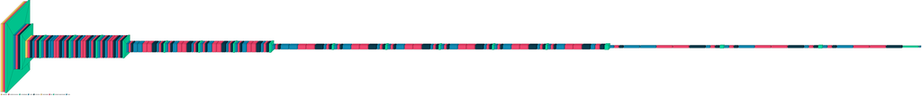

```python
import visualkeras
from PIL import ImageFont
visualkeras.layered_view(model, legend=True)

image = visualkeras.layered_view(model, legend=True)
image.save('model_visual_1.png')
print('ResNet50 Model Architecture Image Saved')
```

## Model 2: DenseNet-121

```python
# Clear previous session (release GPU memory resources by resetting backend state)
k.clear_session()

# Load in DenseNet121
densenet121, preprocess_input = Classifiers.get('densenet121')
```

```python
# Create the base model
base_model = densenet121(input_shape=(img_width, img_height, 3),
                      weights='imagenet', # Use imagenet weights
                      include_top=False)  # Ignore the top layer so we can add our own
```

```python
# Extract the output from the base model we created
x = base_model.output

x = Dense(1000, kernel_regularizer=regularizers.l1_l2(0.01),
                activity_regularizer=regularizers.l2(0.01))(x)

x = Activation('relu')(x)

# Add a Dropout layer to prevent overfitting
#x = Dropout(0.2)(x)

x = Dense(500, kernel_regularizer=regularizers.l1_l2(0.01), activity_regularizer=regularizers.l2(0.01))(x)

x = Activation('relu')(x)

# Add a Pooling Layer to flatten the output of ResNet into 1-D tensor
x = keras.layers.GlobalAveragePooling2D()(x)

# Use Softmax to perform the final layer classification
predictions = Dense(units=train_generator.num_classes,
                    activation= 'softmax')(x)

# Establish the new model with the outputs and base model
model = Model(inputs = base_model.input,
              outputs = predictions)

# Compile the model
model.compile(optimizer = 'sgd',
              loss='categorical_crossentropy',
              metrics=['acc'])

# Show summary
model.summary()
```

```
Model: "model"
__________________________________________________________________________________________________
 Layer (type)                   Output Shape         Param #     Connected to
==================================================================================================
 input_1 (InputLayer)           [(None, 224, 224, 3  0           []
                                )]

 zero_padding2d (ZeroPadding2D)  (None, 230, 230, 3)  0          ['input_1[0][0]']

 conv1/conv (Conv2D)            (None, 112, 112, 64  9408        ['zero_padding2d[0][0]']
                                )

 conv1/bn (BatchNormalization)  (None, 112, 112, 64  256         ['conv1/conv[0][0]']
                                )

 conv1/relu (Activation)        (None, 112, 112, 64  0           ['conv1/bn[0][0]']
                                )

 zero_padding2d_1 (ZeroPadding2  (None, 114, 114, 64  0          ['conv1/relu[0][0]']
 D)                             )

 pool1 (MaxPooling2D)           (None, 56, 56, 64)   0           ['zero_padding2d_1[0][0]']

 conv2_block1_0_bn (BatchNormal  (None, 56, 56, 64)  256         ['pool1[0][0]']
 ization)

 conv2_block1_0_relu (Activatio  (None, 56, 56, 64)  0           ['conv2_block1_0_bn[0][0]']
 n)

 conv2_block1_1_conv (Conv2D)   (None, 56, 56, 128)  8192        ['conv2_block1_0_relu[0][0]']

 conv2_block1_1_bn (BatchNormal  (None, 56, 56, 128)  512        ['conv2_block1_1_conv[0][0]']
 ization)

 conv2_block1_1_relu (Activatio  (None, 56, 56, 128)  0          ['conv2_block1_1_bn[0][0]']
 n)

 conv2_block1_2_conv (Conv2D)   (None, 56, 56, 32)   36864       ['conv2_block1_1_relu[0][0]']

 conv2_block1_concat (Concatena  (None, 56, 56, 96)  0           ['pool1[0][0]',
```

[output cut: 1119 more lines]

```
 dense_1 (Dense)                (None, 7, 7, 500)    500500      ['activation[0][0]']

 activation_1 (Activation)      (None, 7, 7, 500)    0           ['dense_1[0][0]']

 global_average_pooling2d (Glob  (None, 500)         0           ['activation_1[0][0]']
 alAveragePooling2D)

 dense_2 (Dense)                (None, 196)          98196       ['global_average_pooling2d[0][0]'
                                                                 ]

==================================================================================================
Total params: 8,661,200
Trainable params: 8,577,552
Non-trainable params: 83,648
__________________________________________________________________________________________________
```

```python
# Fit the DenseNet121 Model

model_fitted = model.fit(
    train_generator,
    epochs=epochs,
    steps_per_epoch=nb_train_samples // batch_size)
    #validation_data=validation_generator,
    #validation_steps=nb_validation_samples // batch_size)#,
    #callbacks=callbacks_list)
```

```python
# Save Model
model.save('DenseNet121_fitted')
print('Model was successfully saved')
```

```
WARNING:absl:Found untraced functions such as _jit_compiled_convolution_op, _jit_compiled_convolution_op, _jit_compiled_convolution_op, _jit_compiled_convolution_op, _jit_compiled_convolution_op while saving (showing 5 of 121). These functions will not be directly callable after loading.
```

```
INFO:tensorflow:Assets written to: DenseNet121_fitted\assets
```

```
INFO:tensorflow:Assets written to: DenseNet121_fitted\assets
```

```
Model was successfully saved
```

```python
# Load the model
model = load_model('DenseNet121_fitted')
```

```python
# Evaluate on validation images
evals = model.evaluate(validation_generator,
                       batch_size=batch_size)
print('Test Categorical Cross Entropy =', str(evals[0]))
print('Test Accuracy =', str(evals[1]))

evals_train = model.evaluate(train_generator,
                       batch_size=batch_size)
print('Train Categorical Cross Entropy =', str(evals_train[0]))
print('Train Accuracy =', str(evals_train[1]))
```

```
Test Categorical Cross Entropy = nan
Test Accuracy = 0.005471956450492144
Train Categorical Cross Entropy = nan
Train Accuracy = 0.005525540094822645
```

```python
import visualkeras
from PIL import ImageFont
visualkeras.layered_view(model, legend=True)

image = visualkeras.layered_view(model, legend=True)
image.save('model_visual_2.png')
print('DenseNet121 Model Architecture Image Saved')
```

```
DenseNet121 Model Architecture Image Saved
```

## Model 3: ResNet50 - with adjustments

```python
# Create the base model
base_model = ResNet50(input_shape=(img_width, img_height, 3),
                      weights='imagenet', # Use imagenet weights
                      include_top=False)  # Ignore the top layer so we can add our own
```

```python
# Extract the output from the base model we created
x = base_model.output

# Add a Dropout layer to prevent overfitting
x = Dropout(0.30)(x)

# Add a flattening layer but preserve spatial features
x = Flatten()(x)

# Use Softmax to perform the final layer classification
predictions = Dense(units=train_generator.num_classes,
                    activation= 'softmax')(x)

# Establish the new model with the outputs and base model
model = Model(inputs = base_model.input,
              outputs = predictions)

# Compile the model
model.compile(optimizer = 'adam',
              loss = 'categorical_crossentropy',
              metrics = ['acc'])

# Show summary
model.summary()
```

```
Model: "model_2"
__________________________________________________________________________________________________
 Layer (type)                   Output Shape         Param #     Connected to
==================================================================================================
 data (InputLayer)              [(None, 224, 224, 3  0           []
                                )]

 bn_data (BatchNormalization)   (None, 224, 224, 3)  9           ['data[0][0]']

 zero_padding2d (ZeroPadding2D)  (None, 230, 230, 3)  0          ['bn_data[0][0]']

 conv0 (Conv2D)                 (None, 112, 112, 64  9408        ['zero_padding2d[0][0]']
                                )

 bn0 (BatchNormalization)       (None, 112, 112, 64  256         ['conv0[0][0]']
                                )

 relu0 (Activation)             (None, 112, 112, 64  0           ['bn0[0][0]']
                                )

 zero_padding2d_1 (ZeroPadding2  (None, 114, 114, 64  0          ['relu0[0][0]']
 D)                             )

 pooling0 (MaxPooling2D)        (None, 56, 56, 64)   0           ['zero_padding2d_1[0][0]']

 stage1_unit1_bn1 (BatchNormali  (None, 56, 56, 64)  256         ['pooling0[0][0]']
 zation)

 stage1_unit1_relu1 (Activation  (None, 56, 56, 64)  0           ['stage1_unit1_bn1[0][0]']
 )

 stage1_unit1_conv1 (Conv2D)    (None, 56, 56, 64)   4096        ['stage1_unit1_relu1[0][0]']

 stage1_unit1_bn2 (BatchNormali  (None, 56, 56, 64)  256         ['stage1_unit1_conv1[0][0]']
 zation)

 stage1_unit1_relu2 (Activation  (None, 56, 56, 64)  0           ['stage1_unit1_bn2[0][0]']
 )

 zero_padding2d_2 (ZeroPadding2  (None, 58, 58, 64)  0           ['stage1_unit1_relu2[0][0]']
```

[output cut: 480 more lines]

```
 bn1 (BatchNormalization)       (None, 7, 7, 2048)   8192        ['add_15[0][0]']

 relu1 (Activation)             (None, 7, 7, 2048)   0           ['bn1[0][0]']

 dropout_1 (Dropout)            (None, 7, 7, 2048)   0           ['relu1[0][0]']

 flatten_1 (Flatten)            (None, 100352)       0           ['dropout_1[0][0]']

 dense_1 (Dense)                (None, 196)          19669188    ['flatten_1[0][0]']

==================================================================================================
Total params: 43,215,245
Trainable params: 43,169,671
Non-trainable params: 45,574
__________________________________________________________________________________________________
```

```python
model_fitted = model.fit(
    train_generator,
    epochs=30,
    steps_per_epoch=nb_train_samples // batch_size)
```

```python
# Save Model
model.save('ResNetAdjusted_fitted')
print('Model was successfully saved')
```

```
WARNING:absl:Found untraced functions such as _jit_compiled_convolution_op, _jit_compiled_convolution_op, _jit_compiled_convolution_op, _jit_compiled_convolution_op, _jit_compiled_convolution_op while saving (showing 5 of 54). These functions will not be directly callable after loading.
```

```
INFO:tensorflow:Assets written to: ResNetAdjusted_fitted\assets
```

```
INFO:tensorflow:Assets written to: ResNetAdjusted_fitted\assets
```

```
Model was successfully saved
```

```python
# Load the model
model = load_model('ResNetAdjusted_fitted')
```

```python
# Evaluate on validation images
evals = model.evaluate(validation_generator,
                       batch_size=batch_size)
print('Test Categorical Cross Entropy =', str(evals[0]))
print('Test Accuracy =', str(evals[1]))

evals_train = model.evaluate(train_generator,
                       batch_size=batch_size)
print('Train Categorical Cross Entropy =', str(evals_train[0]))
print('Train Accuracy =', str(evals_train[1]))
```

```
Test Categorical Cross Entropy = 8.405791282653809
Test Accuracy = 0.006964307744055986
Train Categorical Cross Entropy = 7.81179141998291
Train Accuracy = 0.009332023561000824
```

```python
import visualkeras
from PIL import ImageFont
visualkeras.layered_view(model, legend=True)

image = visualkeras.layered_view(model, legend=True)
image.save('model_visual_3.png')
print('ResNet50 Adjusted Model Architecture Image Saved')
```

```
ResNet50 Adjusted Model Architecture Image Saved
```